# Visual patterns test analysis

# The study

### Familiarization phase

Participants see 5 stimuli repeated 8 times each. Stimuli consist of a 3x3 grid, with 5 random shapes (circle,triangle,square) placed randomly (any 9 cells) with random color (red,blue,yellow,green,orange,purple).

### Study phase

Participants see the 5 familiar stimuli 5 times each (25) and 50 novel stimuli. They have to judge if the current stimulus is one of the familiars. The novels differ to a differing degree from the familiars: there is 5x2 (two for each familiar) that is wholly different (diffarr). 5x2 that has the same placement of random shapes (sarr), 5x2 same arrangement and shapes (sarrsha), 5x2 same arrangement and colors (sarrcol) 5x2 same arrangement, shapes and colors (colors are randomized, thus, these are not the same as the familiars - sarrshacol).

### Test phase

# Participants

The online task has been started by a total of 69 participants.

We excluded a total of 9 participants due to irregular data (incomplete runs, several runs).

We also excluded some (1) participants as they missed more than 66.3065823 trials (mean + 2*sd of misses by participant).

We also excluded those who recognized less than half of the prototypes in the study phase (0). [inactive - this would drop 14 participants]

We also excluded 3 participants as they overused “maybe” responses in the test phase (more than 33).

This left a total of 56 participants.

The sample had a mean(±sd) age of 23.7924528 ± 6.181108.

## Study phase:

During the study phase, the participants see familiar and novel items.

The original sample of 56 participants produced a mean (±sd) recognition rate of 0.6121429 ± 0.2049454 for familiar pictures.

We use an ANOVA to see if there is a difference in correct rejection for the different novels.

```
## Anova Table (Type 3 tests)
##
## Response: crrate
##   Effect           df  MSE         F  ges p.value
## 1   type 3.57, 196.60 0.02 19.15 *** .107   <.001
## ---
## Signif. codes:  0 '***' 0.001 '**' 0.01 '*' 0.05 '+' 0.1 ' ' 1
##
## Sphericity correction method: GG
```

```
##  contrast             estimate     SE  df t.ratio p.value
##  diffarr - sarr        0.11964 0.0237 220  5.051  <.0001
##  diffarr - sarrcol     0.11071 0.0237 220  4.674  0.0001
##  diffarr - sarrsha     0.20536 0.0237 220  8.669  <.0001
##  diffarr - sarrshacol  0.09286 0.0237 220  3.920  0.0011
##  sarr - sarrcol       -0.00893 0.0237 220 -0.377  0.9957
##  sarr - sarrsha        0.08571 0.0237 220  3.618  0.0034
##  sarr - sarrshacol    -0.02679 0.0237 220 -1.131  0.7901
##  sarrcol - sarrsha     0.09464 0.0237 220  3.995  0.0008
##  sarrcol - sarrshacol -0.01786 0.0237 220 -0.754  0.9433
##  sarrsha - sarrshacol -0.11250 0.0237 220 -4.749  <.0001
##
## P value adjustment: tukey method for comparing a family of 5 estimates
```

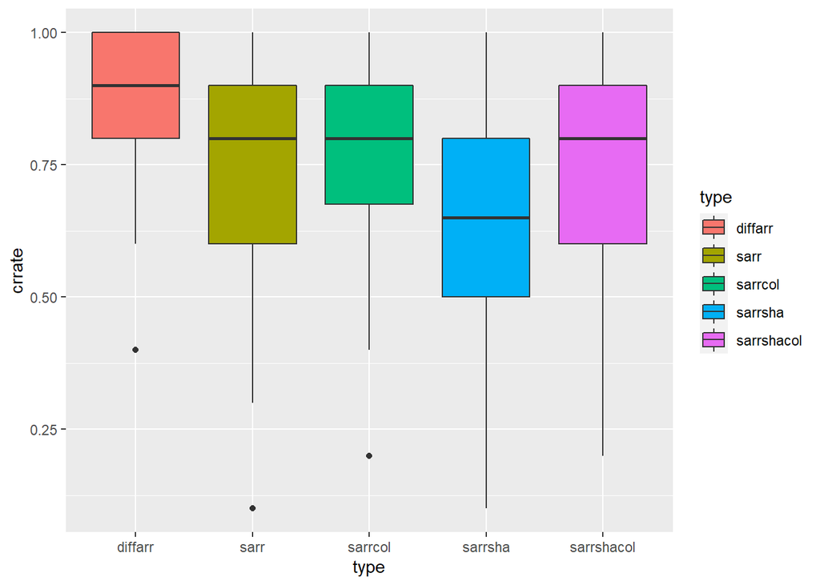

## Test phase:

This phase tests the learning that has occurred during the study phase. If the participants learned the novels in the study phase, their responses should differ for the stimuli that they have already seen during the study phase (familiars) and those that they see for the first time during the test phase (novels). We also let the participants to choose “maybe” by pressing the down arrow, but asked them not to overuse this response (maybe resp <= 50). We added these responses as correct responses to both stimulus categories.

```
## [1] "ANOVA for 'Already Seen' responses"
```

```
## Anova Table (Type 3 tests)
##
## Response: rowCount
##    Effect           df  MSE         F  ges p.value
## 1    type 2.90, 159.57 5.55 30.29 *** .167   <.001
## 2      tq        1, 55 3.45 71.26 *** .092   <.001
## 3 type:tq 3.72, 204.81 2.11  8.01 *** .025   <.001
## ---
## Signif. codes:  0 '***' 0.001 '**' 0.01 '*' 0.05 '+' 0.1 ' ' 1
##
## Sphericity correction method: GG
```

```
##  contrast                        estimate    SE  df t.ratio p.value
##  diffarr,fam - sarr,fam            -0.982 0.327 393 -3.003  0.0831
##  diffarr,fam - sarrcol,fam         -1.321 0.327 393 -4.040  0.0026
##  diffarr,fam - sarrsha,fam         -2.643 0.327 393 -8.079  <.0001
##  diffarr,fam - sarrshacol,fam      -1.464 0.327 393 -4.476  0.0004
##  diffarr,fam - diffarr,new          1.821 0.284 257  6.410  <.0001
##  diffarr,fam - sarr,new             0.839 0.343 378  2.447  0.3010
##  diffarr,fam - sarrcol,new         -0.554 0.343 378 -1.614  0.8407
##  diffarr,fam - sarrsha,new         -0.714 0.343 378 -2.083  0.5408
##  diffarr,fam - sarrshacol,new      -1.179 0.343 378 -3.437  0.0227
##  sarr,fam - sarrcol,fam            -0.339 0.327 393 -1.037  0.9898
##  sarr,fam - sarrsha,fam            -1.661 0.327 393 -5.077  <.0001
##  sarr,fam - sarrshacol,fam         -0.482 0.327 393 -1.474  0.9017
##  sarr,fam - diffarr,new             2.804 0.343 378  8.175  <.0001
##  sarr,fam - sarr,new                1.821 0.284 257  6.410  <.0001
##  sarr,fam - sarrcol,new             0.429 0.343 378  1.250  0.9636
##  sarr,fam - sarrsha,new             0.268 0.343 378  0.781  0.9988
##  sarr,fam - sarrshacol,new         -0.196 0.343 378 -0.573  0.9999
##  sarrcol,fam - sarrsha,fam         -1.321 0.327 393 -4.040  0.0026
##  sarrcol,fam - sarrshacol,fam      -0.143 0.327 393 -0.437  1.0000
##  sarrcol,fam - diffarr,new          3.143 0.343 378  9.164  <.0001
##  sarrcol,fam - sarr,new             2.161 0.343 378  6.301  <.0001
##  sarrcol,fam - sarrcol,new          0.768 0.284 257  2.702  0.1784
##  sarrcol,fam - sarrsha,new          0.607 0.343 378  1.770  0.7535
##  sarrcol,fam - sarrshacol,new       0.143 0.343 378  0.417  1.0000
##  sarrsha,fam - sarrshacol,fam       1.179 0.327 393  3.603  0.0129
##  sarrsha,fam - diffarr,new          4.464 0.343 378 13.018  <.0001
##  sarrsha,fam - sarr,new             3.482 0.343 378 10.154  <.0001
##  sarrsha,fam - sarrcol,new          2.089 0.343 378  6.092  <.0001
##  sarrsha,fam - sarrsha,new          1.929 0.284 257  6.787  <.0001
##  sarrsha,fam - sarrshacol,new       1.464 0.343 378  4.270  0.0010
##  sarrshacol,fam - diffarr,new       3.286 0.343 378  9.581  <.0001
##  sarrshacol,fam - sarr,new          2.304 0.343 378  6.717  <.0001
##  sarrshacol,fam - sarrcol,new       0.911 0.343 378  2.656  0.1960
##  sarrshacol,fam - sarrsha,new       0.750 0.343 378  2.187  0.4676
##  sarrshacol,fam - sarrshacol,new    0.286 0.284 257  1.005  0.9918
##  diffarr,new - sarr,new            -0.982 0.327 393 -3.003  0.0831
##  diffarr,new - sarrcol,new         -2.375 0.327 393 -7.261  <.0001
##  diffarr,new - sarrsha,new         -2.536 0.327 393 -7.752  <.0001
##  diffarr,new - sarrshacol,new      -3.000 0.327 393 -9.171  <.0001
##  sarr,new - sarrcol,new            -1.393 0.327 393 -4.258  0.0011
##  sarr,new - sarrsha,new            -1.554 0.327 393 -4.749  0.0001
##  sarr,new - sarrshacol,new         -2.018 0.327 393 -6.169  <.0001
##  sarrcol,new - sarrsha,new         -0.161 0.327 393 -0.491  1.0000
##  sarrcol,new - sarrshacol,new      -0.625 0.327 393 -1.911  0.6618
##  sarrsha,new - sarrshacol,new      -0.464 0.327 393 -1.419  0.9207
##
## P value adjustment: tukey method for comparing a family of 10 estimates
```

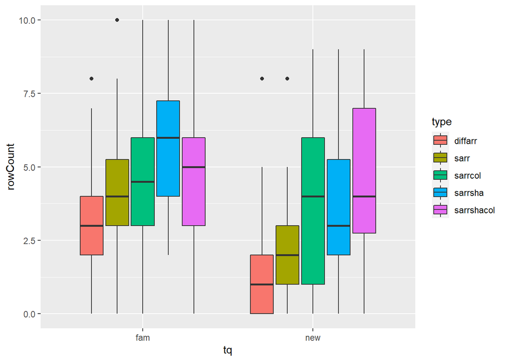

```
## [1] "ANOVA for 'Never Seen' responses"
```

```
## Anova Table (Type 3 tests)
##
## Response: rowCount
##    Effect           df  MSE         F  ges p.value
## 1    type 3.19, 175.38 4.52 39.18 *** .182   <.001
## 2      tq        1, 55 3.31 55.51 *** .067   <.001
## 3 type:tq 3.63, 199.65 2.17  5.28 *** .016   <.001
## ---
## Signif. codes:  0 '***' 0.001 '**' 0.01 '*' 0.05 '+' 0.1 ' ' 1
##
## Sphericity correction method: GG
```

```
##  contrast                        estimate    SE  df t.ratio p.value
##  diffarr,fam - sarr,fam             0.982 0.315 405   3.114 0.0609
##  diffarr,fam - sarrcol,fam          1.339 0.315 405   4.246 0.0011
##  diffarr,fam - sarrsha,fam          2.554 0.315 405   8.095 <.0001
##  diffarr,fam - sarrshacol,fam       1.750 0.315 405   5.548 <.0001
##  diffarr,fam - diffarr,new         -1.786 0.283 260  -6.319 <.0001
##  diffarr,fam - sarr,new            -0.625 0.330 384  -1.892 0.6746
##  diffarr,fam - sarrcol,new          0.732 0.330 384   2.216 0.4474
##  diffarr,fam - sarrsha,new          1.232 0.330 384   3.730 0.0083
##  diffarr,fam - sarrshacol,new       1.339 0.330 384   4.054 0.0024
##  sarr,fam - sarrcol,fam             0.357 0.315 405   1.132 0.9811
##  sarr,fam - sarrsha,fam             1.571 0.315 405   4.982 <.0001
##  sarr,fam - sarrshacol,fam          0.768 0.315 405   2.434 0.3083
##  sarr,fam - diffarr,new            -2.768 0.330 384  -8.379 <.0001
##  sarr,fam - sarr,new               -1.607 0.283 260  -5.687 <.0001
##  sarr,fam - sarrcol,new            -0.250 0.330 384  -0.757 0.9991
##  sarr,fam - sarrsha,new             0.250 0.330 384   0.757 0.9991
##  sarr,fam - sarrshacol,new          0.357 0.330 384   1.081 0.9863
##  sarrcol,fam - sarrsha,fam          1.214 0.315 405   3.850 0.0053
##  sarrcol,fam - sarrshacol,fam       0.411 0.315 405   1.302 0.9529
##  sarrcol,fam - diffarr,new         -3.125 0.330 384  -9.460 <.0001
##  sarrcol,fam - sarr,new            -1.964 0.330 384  -5.946 <.0001
##  sarrcol,fam - sarrcol,new         -0.607 0.283 260  -2.148 0.4952
##  sarrcol,fam - sarrsha,new         -0.107 0.330 384  -0.324 1.0000
##  sarrcol,fam - sarrshacol,new       0.000 0.330 384   0.000 1.0000
##  sarrsha,fam - sarrshacol,fam      -0.804 0.315 405  -2.547 0.2467
##  sarrsha,fam - diffarr,new         -4.339 0.330 384 -13.136 <.0001
##  sarrsha,fam - sarr,new            -3.179 0.330 384  -9.622 <.0001
##  sarrsha,fam - sarrcol,new         -1.821 0.330 384  -5.514 <.0001
##  sarrsha,fam - sarrsha,new         -1.321 0.283 260  -4.676 0.0002
##  sarrsha,fam - sarrshacol,new      -1.214 0.330 384  -3.676 0.0101
##  sarrshacol,fam - diffarr,new      -3.536 0.330 384 -10.703 <.0001
##  sarrshacol,fam - sarr,new         -2.375 0.330 384  -7.189 <.0001
##  sarrshacol,fam - sarrcol,new      -1.018 0.330 384  -3.081 0.0670
##  sarrshacol,fam - sarrsha,new      -0.518 0.330 384  -1.568 0.8629
##  sarrshacol,fam - sarrshacol,new   -0.411 0.283 260  -1.453 0.9088
##  diffarr,new - sarr,new             1.161 0.315 405   3.680 0.0099
##  diffarr,new - sarrcol,new          2.518 0.315 405   7.982 <.0001
##  diffarr,new - sarrsha,new          3.018 0.315 405   9.567 <.0001
##  diffarr,new - sarrshacol,new       3.125 0.315 405   9.907 <.0001
##  sarr,new - sarrcol,new             1.357 0.315 405   4.302 0.0009
##  sarr,new - sarrsha,new             1.857 0.315 405   5.888 <.0001
##  sarr,new - sarrshacol,new          1.964 0.315 405   6.227 <.0001
##  sarrcol,new - sarrsha,new          0.500 0.315 405   1.585 0.8548
##  sarrcol,new - sarrshacol,new       0.607 0.315 405   1.925 0.6521
##  sarrsha,new - sarrshacol,new       0.107 0.315 405   0.340 1.0000
##
## P value adjustment: tukey method for comparing a family of 10 estimates
```

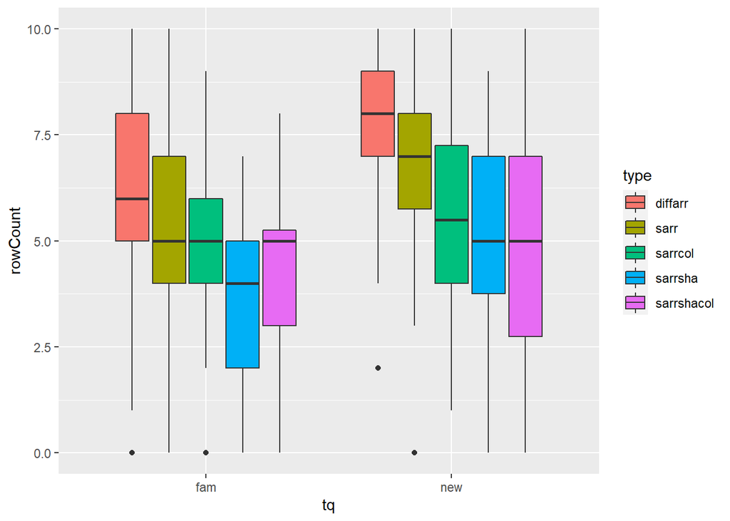

```
## [1] "This plot shows the responses to familiars. left = seen; down = may have seen; right = not seen"
```

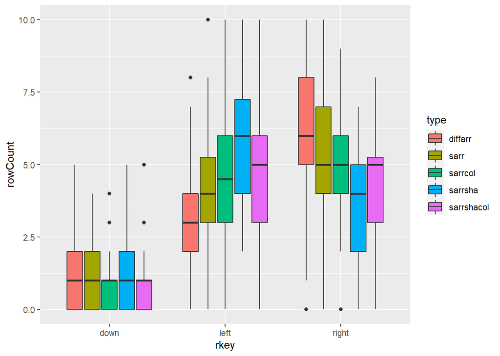

```
## [1] "This plot shows the responses to novels. left = seen; down = may have seen; right = not seen"
```

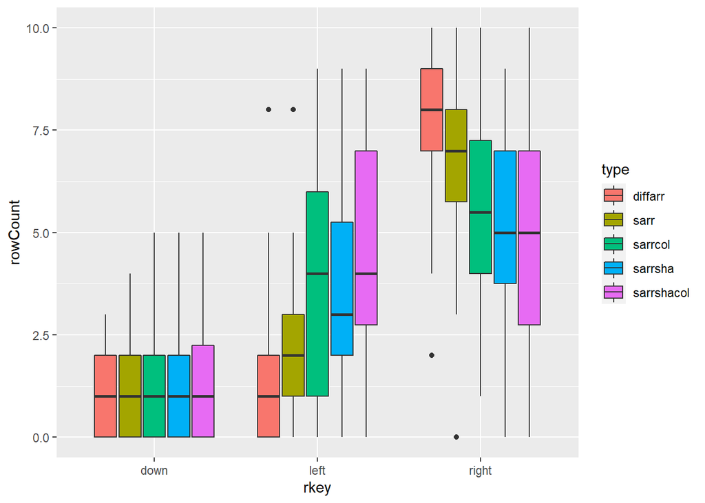

```
## [1] "ANOVA with correct recognition minus false alarm by category"
```

```
## Anova Table (Type 3 tests)
##
## Response: ccr
##   Effect           df  MSE        F  ges p.value
## 1   type 3.70, 214.36 4.25 6.87 *** .070   <.001
## ---
## Signif. codes:  0 '***' 0.001 '**' 0.01 '*' 0.05 '+' 0.1 ' ' 1
##
## Sphericity correction method: GG
```

```
##  contrast             estimate    SE  df t.ratio p.value
##  diffarr - sarr         0.0169 0.365 232  0.046  1.0000
##  diffarr - sarrcol      0.9661 0.365 232  2.647  0.0654
##  diffarr - sarrsha     -0.1186 0.365 232 -0.325  0.9976
##  diffarr - sarrshacol   1.3729 0.365 232  3.761  0.0020
##  sarr - sarrcol         0.9492 0.365 232  2.600  0.0736
##  sarr - sarrsha        -0.1356 0.365 232 -0.371  0.9959
##  sarr - sarrshacol      1.3559 0.365 232  3.715  0.0024
##  sarrcol - sarrsha     -1.0847 0.365 232 -2.972  0.0269
##  sarrcol - sarrshacol   0.4068 0.365 232  1.114  0.7989
##  sarrsha - sarrshacol   1.4915 0.365 232  4.086  0.0006
##
## P value adjustment: tukey method for comparing a family of 5 estimates
```

```
##  contrast  estimate    SE  df t.ratio p.value
##  linear      -2.610 0.816 232 -3.198  0.0016
##  quadratic   -0.915 0.966 232 -0.948  0.3443
##  cubic       -1.644 0.816 232 -2.014  0.0451
##  quartic     -7.576 2.160 232 -3.508  0.0005
```

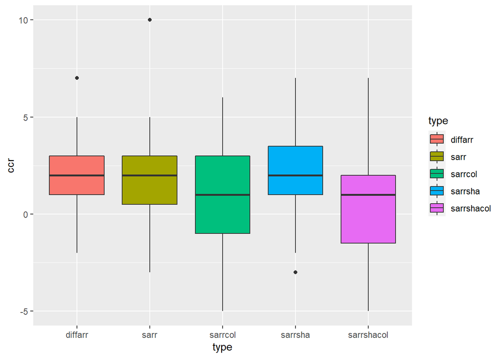

```
## [1] "ANOVA with correct rejection minus false alarm by category"
```

```
## Anova Table (Type 3 tests)
##
## Response: ccr
##   Effect           df  MSE       F  ges p.value
## 1   type 3.63, 210.33 4.31 4.42 ** .045    .003
## ---
## Signif. codes:  0 '***' 0.001 '**' 0.01 '*' 0.05 '+' 0.1 ' ' 1
##
## Sphericity correction method: GG
```

```
##  contrast             estimate    SE  df t.ratio p.value
##  diffarr - sarr          0.153 0.364 232  0.419  0.9935
##  diffarr - sarrcol       1.051 0.364 232  2.888  0.0342
##  diffarr - sarrsha       0.441 0.364 232  1.211  0.7450
##  diffarr - sarrshacol    1.220 0.364 232  3.354  0.0082
##  sarr - sarrcol          0.898 0.364 232  2.469  0.1014
##  sarr - sarrsha          0.288 0.364 232  0.792  0.9328
##  sarr - sarrshacol       1.068 0.364 232  2.935  0.0299
##  sarrcol - sarrsha      -0.610 0.364 232 -1.677  0.4503
##  sarrcol - sarrshacol    0.169 0.364 232  0.466  0.9903
##  sarrsha - sarrshacol    0.780 0.364 232  2.143  0.2057
##
## P value adjustment: tukey method for comparing a family of 5 estimates
```

```
##  contrast  estimate    SE  df t.ratio p.value
##  linear      -2.729 0.814 232 -3.354  0.0009
##  quadratic    0.254 0.963 232  0.264  0.7920
##  cubic       -0.644 0.814 232 -0.792  0.4294
##  quartic     -5.153 2.153 232 -2.394  0.0175
```

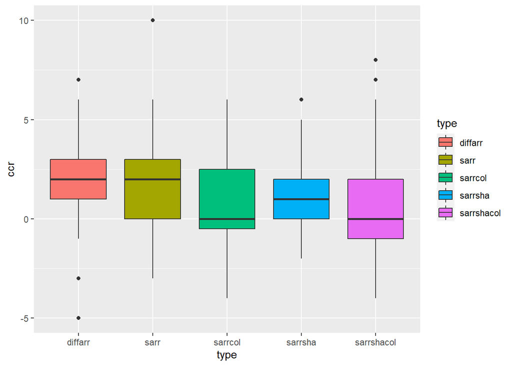

```
## [1] "ANOVA with corrected differentiation score by category ((crecog-fa)+(creject-fa))"
```

```
## Anova Table (Type 3 tests)
##
## Response: occr
##   Effect           df   MSE        F  ges p.value
## 1   type 3.67, 212.72 15.74 5.85 *** .059   <.001
## ---
## Signif. codes:  0 '***' 0.001 '**' 0.01 '*' 0.05 '+' 0.1 ' ' 1
##
## Sphericity correction method: GG
```

```
##  contrast             estimate    SE  df t.ratio p.value
##  diffarr - sarr          0.169 0.699 232  0.242  0.9992
##  diffarr - sarrcol       2.017 0.699 232  2.884  0.0345
##  diffarr - sarrsha       0.322 0.699 232  0.460  0.9907
##  diffarr - sarrshacol    2.593 0.699 232  3.708  0.0024
##  sarr - sarrcol          1.847 0.699 232  2.642  0.0663
##  sarr - sarrsha          0.153 0.699 232  0.218  0.9995
##  sarr - sarrshacol       2.424 0.699 232  3.466  0.0056
##  sarrcol - sarrsha      -1.695 0.699 232 -2.424  0.1127
##  sarrcol - sarrshacol    0.576 0.699 232  0.824  0.9230
##  sarrsha - sarrshacol    2.271 0.699 232  3.248  0.0116
##
## P value adjustment: tukey method for comparing a family of 5 estimates
```

```
##  contrast  estimate   SE  df t.ratio p.value
##  linear      -5.339 1.56 232 -3.414  0.0008
##  quadratic   -0.661 1.85 232 -0.357  0.7212
##  cubic       -2.288 1.56 232 -1.463  0.1448
##  quartic    -12.729 4.14 232 -3.077  0.0023
```

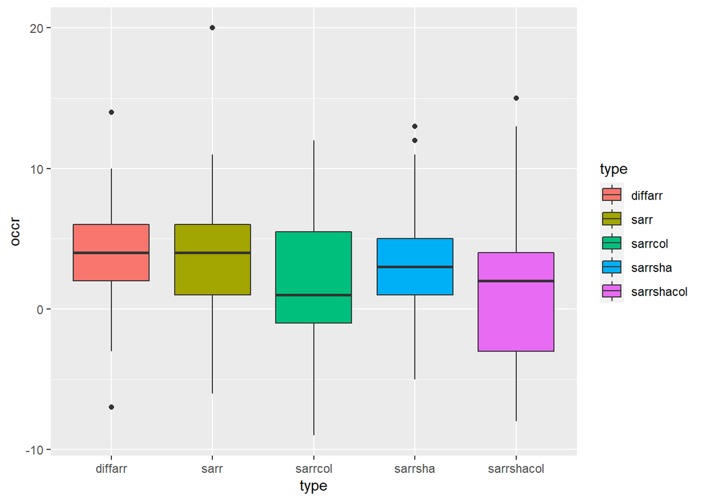

```
## [1] "The mean difference by category"
```

```
##          type    V1
## 1:    sarrsha  4.25
## 2: sarrshacol  3.40
## 3:       sarr  7.30
## 4:    diffarr 12.35
## 5:    sarrcol  3.25
```

```
## Generalized linear mixed model fit by maximum likelihood (Laplace
##   Approximation) [glmerMod]
##  Family: binomial  ( logit )
## Formula: correct_response ~ difference_from_fams + (1 | workerId)
##    Data: tdlmm
##
##      AIC      BIC   logLik deviance df.resid
##   7725.6   7745.5  -3859.8   7719.6     5597
##
## Scaled residuals:
##     Min      1Q  Median      3Q     Max
## -1.4148 -1.0284  0.8095  0.9419  1.2139
##
## Random effects:
##  Groups   Name        Variance Std.Dev.
##  workerId (Intercept) 0.04909  0.2216
## Number of obs: 5600, groups:  workerId, 56
##
## Fixed effects:
##                       Estimate Std. Error z value Pr(>|z|)
## (Intercept)          -0.052922   0.060731  -0.871  0.38353
## difference_from_fams  0.023365   0.007498   3.116  0.00183 **
## ---
## Signif. codes:  0 '***' 0.001 '**' 0.01 '*' 0.05 '.' 0.1 ' ' 1
##
## Correlation of Fixed Effects:
##             (Intr)
## dffrnc_frm_ -0.752
```

```
## Package `effects` is not available, but needed for `ggeffect()`. Either install package `effects`, or use `ggpredict()`. Calling `ggpredict()` now.FALSE
```

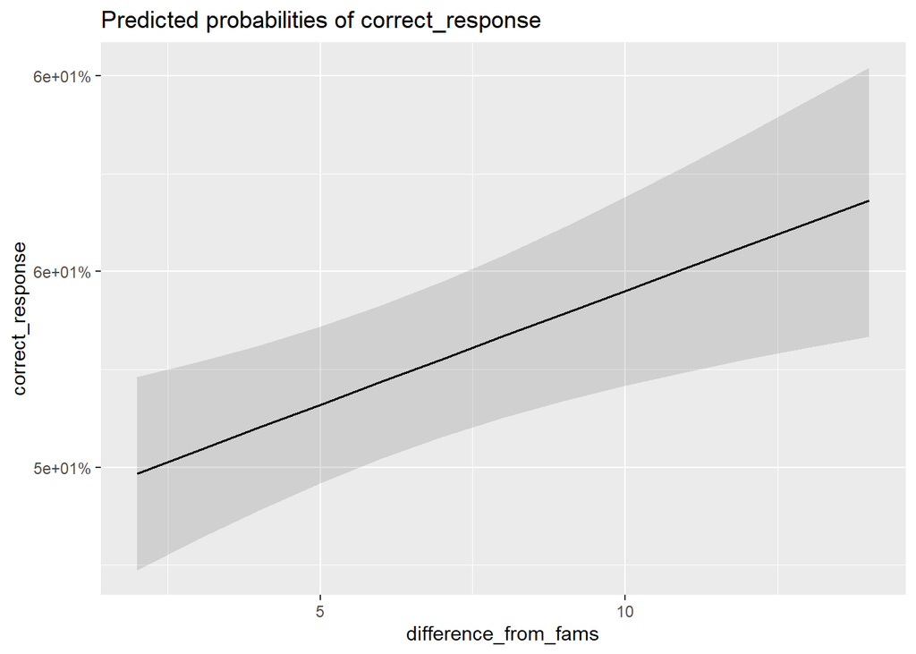

```
## Generalized linear mixed model fit by maximum likelihood (Laplace
##   Approximation) [glmerMod]
##  Family: binomial  ( logit )
## Formula: correct_response ~ difference_from_fams * trial_quality + (1 |
##     workerId) + (1 | difference_from_fams)
##    Data: tdlmm
##
##      AIC      BIC   logLik deviance df.resid
##   7375.8   7415.6  -3681.9   7363.8     5594
##
## Scaled residuals:
##     Min      1Q  Median      3Q     Max
## -2.4168 -0.9588  0.4758  0.9392  1.9386
##
## Random effects:
##  Groups               Name        Variance Std.Dev.
##  workerId             (Intercept) 0.05961  0.2442
##  difference_from_fams (Intercept) 0.01225  0.1107
## Number of obs: 5600, groups:  workerId, 56; difference_from_fams, 13
##
## Fixed effects:
##                                       Estimate Std. Error z value Pr(>|z|)
## (Intercept)                            0.27190    0.11347   2.396   0.0166 *
## difference_from_fams                  -0.08800    0.01432  -6.146 7.94e-10 ***
## trial_qualitynew                      -0.75672    0.11224  -6.742 1.56e-11 ***
## difference_from_fams:trial_qualitynew  0.23535    0.01680  14.011  < 2e-16 ***
## ---
## Signif. codes:  0 '***' 0.001 '**' 0.01 '*' 0.05 '.' 0.1 ' ' 1
##
## Correlation of Fixed Effects:
##             (Intr) dffr__ trl_ql
## dffrnc_frm_ -0.833
## tril_qltynw -0.452  0.460
## dffrnc_f_:_  0.383 -0.534 -0.862
```

```
## Package `effects` is not available, but needed for `ggeffect()`. Either install package `effects`, or use `ggpredict()`. Calling `ggpredict()` now.FALSE
```

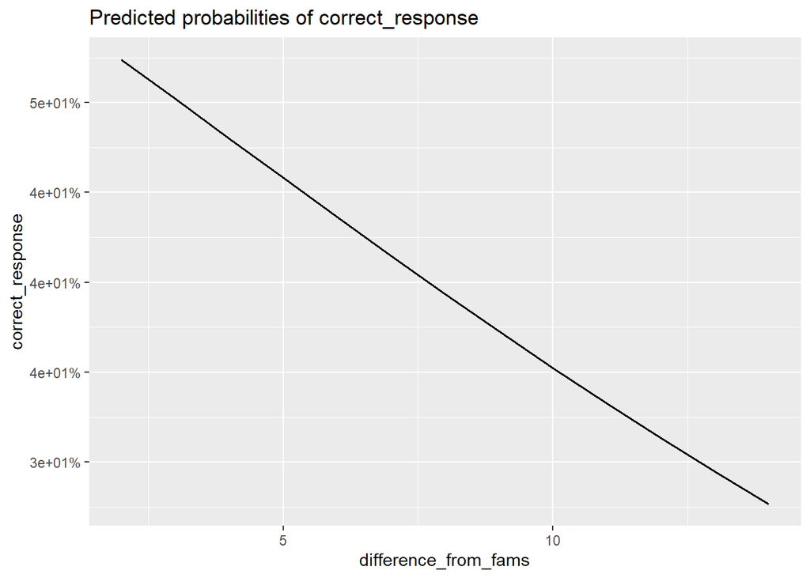

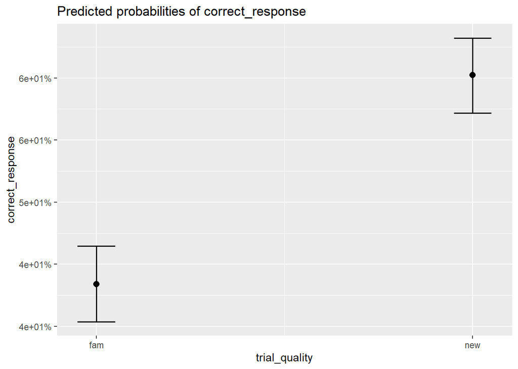

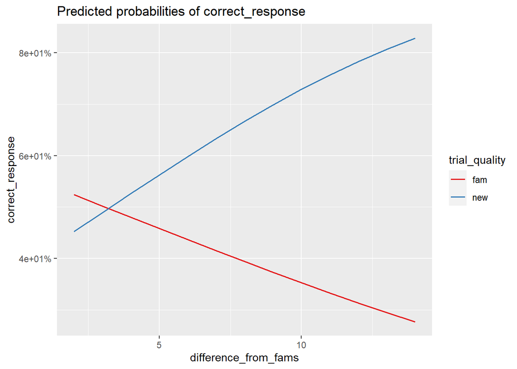

|  | correct_response |  |  |  | correct_response |  |  |  |
| --- | --- | --- | --- | --- | --- | --- | --- | --- |
| Predictors | Log-Odds | std. Error | CI | p | Log-Odds | std. Error | CI | p |
| (Intercept) | 0.27 | 0.11 | 0.05 – 0.49 | **0.017** | -0.05 | 0.06 | -0.17 – 0.07 | 0.384 |
| difference_from_fams | -0.09 | 0.01 | -0.12 – -0.06 | **<0.001** | 0.02 | 0.01 | 0.01 – 0.04 | **0.002** |
| trial_quality [new] | -0.76 | 0.11 | -0.98 – -0.54 | **<0.001** |  |  |  |  |
| difference_from_fams * trial_quality [new] | 0.24 | 0.02 | 0.20 – 0.27 | **<0.001** |  |  |  |  |
| Random Effects |  |  |  |  |  |  |  |  |
| σ<sup>2</sup> | 3.29 |  |  |  | 3.29 |  |  |  |
| τ<sub>00</sub> | 0.06 <sub>workerId</sub> |  |  |  | 0.05 <sub>workerId</sub> |  |  |  |
|  | 0.01 <sub>difference_from_fams</sub> |  |  |  |  |  |  |  |
| ICC | 0.02 |  |  |  | 0.01 |  |  |  |
| N | 56 <sub>workerId</sub> |  |  |  | 56 <sub>workerId</sub> |  |  |  |
|  | 13 <sub>difference_from_fams</sub> |  |  |  |  |  |  |  |
| Observations | 5600 |  |  |  | 5600 |  |  |  |
| Marginal R<sup>2</sup> / Conditional R<sup>2</sup> | 0.084 / 0.104 |  |  |  | 0.002 / 0.017 |  |  |  |
| AIC | 7375.842 |  |  |  | 7725.632 |  |  |  |

The difference in correct recognitions and correct rejections between categories is due to the fact that they are more or less similar to the prototypes (thus this may be the effect of the familiarization phase which we also saw in the study phase).

During the task the participants generate predictions as to what happens next (not due to the instructions but automatically). Those stimuli that are most different from most of the stimuli should be remembered better.

By calculating a the number of correct recognitions (old - seen) and correct rejections (new - not seen) and correcting these numbers with the respective false alarm rates (new - seen; old - not seen) and adding these we get a number that reflects how well the participants distinguished pictures in the test phase. These numbers are very low (below 5 which translates to a rating of about 0.25 - the corrected rate of correct categorizations - max would be 20 for a category), which suggests that the task was hard. Yet there are differences in this number between the categories which shows that some categories were more likely to be correctly categorized. We would expect that diffarf would be the highest, while sharrshacol the lowest, with a gradual decrease through the other categories. This is partly supported by the data, but the experiment should be repeated with an easier stimulus set.